# Part I - (Communicate Data findings)

## Introduction

The dataset includes information about individual rides made in a bike- sharing system covering different locations stated below.

The datasets I chose for this project are 5 in number which includes:

> The ford Go Bike System Data from San Francisco Bay Area,

> The Divvy Trips from Chicago, Illinois

> The Citibike Trip data from New York City

> The Capital Bike Share trip data from washington Dc Metro Area.

> The Cogo trip data from Columbus,Ohio.

## Preliminary Wrangling

```python
# import all packages and set plots to be embedded inline
import numpy as np
import pandas as pd
import matplotlib.pyplot as plt
import seaborn as sns
import csv

%matplotlib inline
```

```python
#loading the dataset for the Chicago, Illinois bike ride
df_1=pd.read_csv('Divvy_Trips_2019_Q1.csv')
```

```python
#Changing the datatypes for the time columns to datetime format
df_1.start_time=pd.to_datetime(df_1.start_time)
df_1.end_time=pd.to_datetime(df_1.end_time)
```

```python
#the dataset reads first quarter of 2019, but we only need 2019-02 which is february
# so we'll filter, 2019-02 from the whole dataframe
df_1=df_1[df_1['start_time'] < '2019-03-01']
df_1=df_1[df_1['start_time'] > '2019-02-01']
```

```python
#to add the Area(location of the dataset)
df_1['location']= 'Chicago,Illinois'
```

```python
#we need to rename some columns to make them uniform to the rest of the dataframes we intend merging
df_1.rename(columns={'bikeid':'bike_id','tripduration':'trip_duration','from_station_id':'start_station_id', 'to_station_id':'end_station_id',\
                     'from_station_name':'start_station_name', 'to_station_name':'end_station_name', 'usertype':'user_type','birthyear':'birth_year'}, inplace=True)
```

```python
#information of the dataset
df_1.info()
```

```
<class 'pandas.core.frame.DataFrame'>
Int64Index: 96186 entries, 103270 to 199457
Data columns (total 13 columns):
 #   Column              Non-Null Count  Dtype
---  ------              --------------  -----
 0   trip_id             96186 non-null  int64
 1   start_time          96186 non-null  datetime64[ns]
 2   end_time            96186 non-null  datetime64[ns]
 3   bike_id             96186 non-null  int64
 4   trip_duration       96186 non-null  object
 5   start_station_id    96186 non-null  int64
 6   start_station_name  96186 non-null  object
 7   end_station_id      96186 non-null  int64
 8   end_station_name    96186 non-null  object
 9   user_type           96186 non-null  object
 10  gender              93513 non-null  object
 11  birth_year          94028 non-null  float64
 12  location            96186 non-null  object
dtypes: datetime64[ns](2), float64(1), int64(4), object(6)
memory usage: 10.3+ MB
```

```python
##loading the dataset for the San Francisco Bay Area bike ride
df_2=pd.read_csv('201902-fordgobike-tripdata.csv')
```

```python
# we need to change the datatype for the time columns to datetime
df_2.start_time=pd.to_datetime(df_2.start_time)
df_2.end_time=pd.to_datetime(df_2.end_time)
```

```python
#to add the Area(location of the dataset)
df_2['location']= 'San Francisco Bay Area'
```

```python
#inforamtion of the dataset
df_2.info()
```

```
<class 'pandas.core.frame.DataFrame'>
RangeIndex: 183412 entries, 0 to 183411
Data columns (total 17 columns):
 #   Column                   Non-Null Count   Dtype
---  ------                   --------------   -----
 0   duration_sec             183412 non-null  int64
 1   start_time               183412 non-null  datetime64[ns]
 2   end_time                 183412 non-null  datetime64[ns]
 3   start_station_id         183215 non-null  float64
 4   start_station_name       183215 non-null  object
 5   start_station_latitude   183412 non-null  float64
 6   start_station_longitude  183412 non-null  float64
 7   end_station_id           183215 non-null  float64
 8   end_station_name         183215 non-null  object
 9   end_station_latitude     183412 non-null  float64
 10  end_station_longitude    183412 non-null  float64
 11  bike_id                  183412 non-null  int64
 12  user_type                183412 non-null  object
 13  member_birth_year        175147 non-null  float64
 14  member_gender            175147 non-null  object
 15  bike_share_for_all_trip  183412 non-null  object
 16  location                 183412 non-null  object
dtypes: datetime64[ns](2), float64(7), int64(2), object(6)
memory usage: 23.8+ MB
```

```python
#we need to change some column names for uniformity of the whole dataset we intend merging
df_2.rename(columns={'duration_sec':'trip_duration','member_birth_year':'birth_year','member_gender': 'gender'}, inplace=True)
```

```python
df_2.head(2)
```

|  | trip_duration | start_time | end_time | start_station_id | start_station_name | start_station_latitude | start_station_longitude | end_station_id | end_station_name | end_station_latitude | end_station_longitude | bike_id | user_type | birth_year | gender | bike_share_for_all_trip | location |
| --- | --- | --- | --- | --- | --- | --- | --- | --- | --- | --- | --- | --- | --- | --- | --- | --- | --- |
| 0 | 52185 | 2019-02-28 17:32:10.145 | 2019-03-01 08:01:55.975 | 21.0 | Montgomery St BART Station (Market St at 2nd St) | 37.789625 | -122.400811 | 13.0 | Commercial St at Montgomery St | 37.794231 | -122.402923 | 4902 | Customer | 1984.0 | Male | No | San Francisco Bay Area |
| 1 | 42521 | 2019-02-28 18:53:21.789 | 2019-03-01 06:42:03.056 | 23.0 | The Embarcadero at Steuart St | 37.791464 | -122.391034 | 81.0 | Berry St at 4th St | 37.775880 | -122.393170 | 2535 | Customer | NaN | NaN | No | San Francisco Bay Area |

```python
#loading the dataset for the Newyork City bike ride
df_3=pd.read_csv('201902-citibike-tripdata.csv',  quoting=csv.QUOTE_NONE)
```

```python
#to add the Area(location of the dataset)
df_3['location']= 'New York City'
```

```python
#we need to change the column name for uniformity of the whole datasets
df_3.rename(columns={'"tripduration"':'trip_duration', '"starttime"':'start_time', '"stoptime"':'end_time', '"start station id"':'start_station_id', '"start station name"':'start_station_name', '"start station latitude"':'start_station_latitude', '"start station longitude"':'start_station_longitude', '"end station id"':'end_station_id', '"end station name"':'end_station_name', '"end station latitude"':'end_station_latitude', '"end station longitude"':'end_station_longitude', '"bikeid"':'bike_id','"usertype"':'user_type', '"birth year"':'birth_year', '"gender"':'gender' }, inplace=True)
```

```python
df_3.head(2)
```

|  | trip_duration | start_time | end_time | start_station_id | start_station_name | start_station_latitude | start_station_longitude | end_station_id | end_station_name | end_station_latitude | end_station_longitude | bike_id | user_type | birth_year | gender | location |
| --- | --- | --- | --- | --- | --- | --- | --- | --- | --- | --- | --- | --- | --- | --- | --- | --- |
| 0 | 219 | "2019-02-01 00:00:06.2570" | "2019-02-01 00:03:46.1090" | 3494.0 | "E 115 St & Lexington Ave" | 40.797911 | -73.942300 | 3501.0 | "E 118 St & Madison Ave" | 40.801487 | -73.944251 | 33450 | "Subscriber" | 1989 | 1 | New York City |
| 1 | 143 | "2019-02-01 00:00:28.0320" | "2019-02-01 00:02:51.7460" | 438.0 | "St Marks Pl & 1 Ave" | 40.727791 | -73.985649 | 236.0 | "St Marks Pl & 2 Ave" | 40.728419 | -73.987140 | 25626 | "Subscriber" | 1990 | 1 | New York City |

```python
# The data contained in the dataset is seen to contain quotes
# we need to remove the quotes by replacing them with no quote
df_3['start_time']=df_3['start_time'].str.replace('"','')
df_3['end_time']=df_3['end_time'].str.replace('"','')
df_3['start_station_name']=df_3['start_station_name'].str.replace('"','')
df_3['end_station_name']=df_3['end_station_name'].str.replace('"','')
df_3['user_type']=df_3['user_type'].str.replace('"','')
```

```python
df_3.head(2)
```

|  | trip_duration | start_time | end_time | start_station_id | start_station_name | start_station_latitude | start_station_longitude | end_station_id | end_station_name | end_station_latitude | end_station_longitude | bike_id | user_type | birth_year | gender | location |
| --- | --- | --- | --- | --- | --- | --- | --- | --- | --- | --- | --- | --- | --- | --- | --- | --- |
| 0 | 219 | 2019-02-01 00:00:06.2570 | 2019-02-01 00:03:46.1090 | 3494.0 | E 115 St & Lexington Ave | 40.797911 | -73.942300 | 3501.0 | E 118 St & Madison Ave | 40.801487 | -73.944251 | 33450 | Subscriber | 1989 | 1 | New York City |
| 1 | 143 | 2019-02-01 00:00:28.0320 | 2019-02-01 00:02:51.7460 | 438.0 | St Marks Pl & 1 Ave | 40.727791 | -73.985649 | 236.0 | St Marks Pl & 2 Ave | 40.728419 | -73.987140 | 25626 | Subscriber | 1990 | 1 | New York City |

```python
# we need to change the time columns to datetime datatype
df_3.start_time=pd.to_datetime(df_3.start_time)
df_3.end_time=pd.to_datetime(df_3.end_time)
```

```python
#for uniformity with the rest of the datasets
#we need to replace the 0,1,2 for Other, Male and Female respectively
# as seen from the source of the dataset
df_3.gender=df_3.gender.replace([0,1,2], ('Other', 'Male', 'Female'))
```

```python
df_3.head()
```

|  | trip_duration | start_time | end_time | start_station_id | start_station_name | start_station_latitude | start_station_longitude | end_station_id | end_station_name | end_station_latitude | end_station_longitude | bike_id | user_type | birth_year | gender | location |
| --- | --- | --- | --- | --- | --- | --- | --- | --- | --- | --- | --- | --- | --- | --- | --- | --- |
| 0 | 219 | 2019-02-01 00:00:06.257 | 2019-02-01 00:03:46.109 | 3494.0 | E 115 St & Lexington Ave | 40.797911 | -73.942300 | 3501.0 | E 118 St & Madison Ave | 40.801487 | -73.944251 | 33450 | Subscriber | 1989 | Male | New York City |
| 1 | 143 | 2019-02-01 00:00:28.032 | 2019-02-01 00:02:51.746 | 438.0 | St Marks Pl & 1 Ave | 40.727791 | -73.985649 | 236.0 | St Marks Pl & 2 Ave | 40.728419 | -73.987140 | 25626 | Subscriber | 1990 | Male | New York City |
| 2 | 296 | 2019-02-01 00:01:13.987 | 2019-02-01 00:06:10.734 | 3571.0 | Bedford Ave & Bergen St | 40.676368 | -73.952918 | 3549.0 | Grand Ave & Bergen St | 40.678045 | -73.962408 | 35568 | Subscriber | 1987 | Male | New York City |
| 3 | 478 | 2019-02-01 00:01:14.152 | 2019-02-01 00:09:12.787 | 167.0 | E 39 St & 3 Ave | 40.748901 | -73.976049 | 477.0 | W 41 St & 8 Ave | 40.756405 | -73.990026 | 25045 | Subscriber | 1964 | Female | New York City |
| 4 | 225 | 2019-02-01 00:01:49.341 | 2019-02-01 00:05:34.498 | 3458.0 | W 55 St & 6 Ave | 40.763094 | -73.978350 | 3443.0 | W 52 St & 6 Ave | 40.761330 | -73.979820 | 34006 | Subscriber | 1979 | Male | New York City |

```python
#loading the dataset for the Washington DC Metro Area bike ride
df_4=pd.read_csv('201902-capitalbikeshare-tripdata.csv')
```

```python
df_4.head()
```

|  | Duration | Start date | End date | Start station number | Start station | End station number | End station | Bike number | Member type |
| --- | --- | --- | --- | --- | --- | --- | --- | --- | --- |
| 0 | 206 | 2019-02-01 00:00:20 | 2019-02-01 00:03:47 | 31509 | New Jersey Ave & R St NW | 31636 | New Jersey Ave & N St NW/Dunbar HS | W21713 | Member |
| 1 | 297 | 2019-02-01 00:04:40 | 2019-02-01 00:09:38 | 31203 | 14th & Rhode Island Ave NW | 31519 | 1st & O St NW | E00013 | Member |
| 2 | 165 | 2019-02-01 00:06:34 | 2019-02-01 00:09:20 | 31303 | Tenleytown / Wisconsin Ave & Albemarle St NW | 31308 | 39th & Veazey St NW | W21703 | Member |
| 3 | 176 | 2019-02-01 00:06:49 | 2019-02-01 00:09:45 | 31400 | Georgia & New Hampshire Ave NW | 31401 | 14th St & Spring Rd NW | W21699 | Member |
| 4 | 105 | 2019-02-01 00:10:41 | 2019-02-01 00:12:27 | 31270 | 8th & D St NW | 31256 | 10th & E St NW | W21710 | Member |

```python
#to add the Area(location of the dataset)
df_4['location']= 'Washington DC Metro Area'
```

```python
# To change the column names to meet uniformity with the rest of the datasets
df_4.rename(columns={'Duration':'trip_duration','Start date':'start_time', 'End date':'end_time', 'Start station number':'start_station_id', 'Start station':'start_station_name','End station number':'end_station_id', 'End station':'end_station_name','Bike number':'bike_id', 'Member type':'user_type'  }, inplace=True)
```

```python
#the time columns need to be in datatime datatype
df_4.start_time=pd.to_datetime(df_4.start_time)
df_4.end_time=pd.to_datetime(df_4.end_time)
```

```python
#To test
df_4.dtypes
```

```
trip_duration                  int64
start_time            datetime64[ns]
end_time              datetime64[ns]
start_station_id               int64
start_station_name            object
end_station_id                 int64
end_station_name              object
bike_id                       object
user_type                     object
location                      object
dtype: object
```

```python
df_4.head(2)
```

|  | trip_duration | start_time | end_time | start_station_id | start_station_name | end_station_id | end_station_name | bike_id | user_type | location |
| --- | --- | --- | --- | --- | --- | --- | --- | --- | --- | --- |
| 0 | 206 | 2019-02-01 00:00:20 | 2019-02-01 00:03:47 | 31509 | New Jersey Ave & R St NW | 31636 | New Jersey Ave & N St NW/Dunbar HS | W21713 | Member | Washington DC Metro Area |
| 1 | 297 | 2019-02-01 00:04:40 | 2019-02-01 00:09:38 | 31203 | 14th & Rhode Island Ave NW | 31519 | 1st & O St NW | E00013 | Member | Washington DC Metro Area |

```python
##loading the dataset for the Columbus, Ohio bike ride
df_5=pd.read_csv('201902-cogo-tripdata.csv')
```

```python
#to change the datatype for the time columns to datatime
df_5.start_time=pd.to_datetime(df_5.start_time)
df_5.end_time=pd.to_datetime(df_5.end_time)
```

```python
#to add the Area(location of the dataset)
df_5['location']= 'Columbus,Ohio'
```

```python
#spliting the Station location columns to latitude and longitude
df_5[['start_station_latitude','start_station_longitude']]=df_5['from_station_location'].str.split(',', 1, expand=True)
df_5[['end_station_latitude','end_station_longitude']]=df_5['to_station_location'].str.split(',', 1, expand=True)
```

```python
# we need to drop the two station locations
df_5.drop(['from_station_location', 'to_station_location'],axis=1, inplace=True)
```

```python
#we need to rename some columns for uniformity with the rest of the datasets
df_5.rename(columns={'bikeid':'bike_id', 'tripduration':'trip_duration', 'from_station_id':'start_station_id','to_station_id':'end_station_id','from_station_name':'start_station_name','to_station_name':'end_station_name', 'usertype':'user_type','birthyear':'birth_year'}, inplace=True)
```

```python
#Test
df_5.head(2)
```

|  | trip_id | start_time | end_time | bike_id | trip_duration | start_station_id | start_station_name | end_station_id | end_station_name | user_type | gender | birth_year | location | start_station_latitude | start_station_longitude | end_station_latitude | end_station_longitude |
| --- | --- | --- | --- | --- | --- | --- | --- | --- | --- | --- | --- | --- | --- | --- | --- | --- | --- |
| 0 | 359178 | 2019-02-01 06:44:11 | 2019-02-01 06:50:01 | 250 | 350.0 | 15 | Grant Ave & Main St | 9 | Columbus Commons - Rich St | Subscriber | Male | 1965.0 | Columbus,Ohio | 39.957493 | -82.990057 | 39.957591 | -82.998002 |
| 1 | 359179 | 2019-02-01 08:46:07 | 2019-02-01 08:56:08 | 556 | 601.0 | 55 | Michigan Ave & 3rd Ave | 53 | Neil Ave & 11th Ave | Subscriber | Male | 1966.0 | Columbus,Ohio | 39.984053 | -83.01692 | 39.99543 | -83.014548 |

```python
# we will now merge df_1 to df_5 to achieve df_6
df_6=df_1.merge(df_5, how='outer')
```

```python
df_6.head(2)
```

|  | trip_id | start_time | end_time | bike_id | trip_duration | start_station_id | start_station_name | end_station_id | end_station_name | user_type | gender | birth_year | location | start_station_latitude | start_station_longitude | end_station_latitude | end_station_longitude |
| --- | --- | --- | --- | --- | --- | --- | --- | --- | --- | --- | --- | --- | --- | --- | --- | --- | --- |
| 0 | 21864667 | 2019-02-01 00:08:40 | 2019-02-01 00:14:03 | 4715 | 323.0 | 283 | LaSalle St & Jackson Blvd | 174 | Canal St & Madison St | Subscriber | Male | 1990.0 | Chicago,Illinois | NaN | NaN | NaN | NaN |
| 1 | 21864668 | 2019-02-01 00:10:18 | 2019-02-01 07:49:27 | 2319 | 27,549.0 | 125 | Rush St & Hubbard St | 125 | Rush St & Hubbard St | Subscriber | Male | 1985.0 | Chicago,Illinois | NaN | NaN | NaN | NaN |

```python
#we will now merge df_2 to df_3 to acheive df_7
df_7=df_2.merge(df_3, how='outer')
```

```python
df_7.info()
```

```
<class 'pandas.core.frame.DataFrame'>
Int64Index: 1127156 entries, 0 to 1127155
Data columns (total 17 columns):
 #   Column                   Non-Null Count    Dtype
---  ------                   --------------    -----
 0   trip_duration            1127156 non-null  int64
 1   start_time               1127156 non-null  datetime64[ns]
 2   end_time                 1127156 non-null  datetime64[ns]
 3   start_station_id         1126950 non-null  float64
 4   start_station_name       1126950 non-null  object
 5   start_station_latitude   1127156 non-null  float64
 6   start_station_longitude  1127156 non-null  float64
 7   end_station_id           1126950 non-null  float64
 8   end_station_name         1126950 non-null  object
 9   end_station_latitude     1127156 non-null  float64
 10  end_station_longitude    1127156 non-null  float64
 11  bike_id                  1127156 non-null  int64
 12  user_type                1127156 non-null  object
 13  birth_year               1118891 non-null  float64
 14  gender                   1118891 non-null  object
 15  bike_share_for_all_trip  183412 non-null   object
 16  location                 1127156 non-null  object
dtypes: datetime64[ns](2), float64(7), int64(2), object(6)
memory usage: 154.8+ MB
```

```python
df_7.head(2)
```

|  | trip_duration | start_time | end_time | start_station_id | start_station_name | start_station_latitude | start_station_longitude | end_station_id | end_station_name | end_station_latitude | end_station_longitude | bike_id | user_type | birth_year | gender | bike_share_for_all_trip | location |
| --- | --- | --- | --- | --- | --- | --- | --- | --- | --- | --- | --- | --- | --- | --- | --- | --- | --- |
| 0 | 52185 | 2019-02-28 17:32:10.145 | 2019-03-01 08:01:55.975 | 21.0 | Montgomery St BART Station (Market St at 2nd St) | 37.789625 | -122.400811 | 13.0 | Commercial St at Montgomery St | 37.794231 | -122.402923 | 4902 | Customer | 1984.0 | Male | No | San Francisco Bay Area |
| 1 | 42521 | 2019-02-28 18:53:21.789 | 2019-03-01 06:42:03.056 | 23.0 | The Embarcadero at Steuart St | 37.791464 | -122.391034 | 81.0 | Berry St at 4th St | 37.775880 | -122.393170 | 2535 | Customer | NaN | NaN | No | San Francisco Bay Area |

```python
# we want to merge df_4 and df_7, but we need to change the datatype of bike ID
#for df_7 to str
df_7.bike_id=df_7.bike_id.astype(str)
```

```python
#to test
df_7.bike_id.dtypes
```

```
dtype('O')
```

```python
#we merge df_4 to df_7(df_2+df_3) to achieve df_8
df_8=df_4.merge(df_7, how='outer')
```

```python
#we need to change the datatype of bike_d for df_6(df_1+df_5) to str
df_6.bike_id=df_6.bike_id.astype(str)
#the trip_duration datatype also needs to be changed
df_6.trip_duration=df_6.trip_duration.str.replace(',','')
df_6.trip_duration=df_6.trip_duration.astype(float)
```

```python
#to change the datatypes for the latitudes and longitudes of df_6 to conform to that of df_8
df_6.start_station_latitude=df_6.start_station_latitude.astype(float)
df_6.end_station_latitude=df_6.end_station_latitude.astype(float)
df_6.start_station_longitude=df_6.start_station_longitude.astype(float)
df_6.end_station_longitude=df_6.end_station_longitude.astype(float)
```

```python
#to merge df_6(df_1+df_5) to df_8(df_2+df_3+df_4) to achieve df
df=df_6.merge(df_8, how='outer')
```

```python
df.head()
```

|  | trip_id | start_time | end_time | bike_id | trip_duration | start_station_id | start_station_name | end_station_id | end_station_name | user_type | gender | birth_year | location | start_station_latitude | start_station_longitude | end_station_latitude | end_station_longitude | bike_share_for_all_trip |
| --- | --- | --- | --- | --- | --- | --- | --- | --- | --- | --- | --- | --- | --- | --- | --- | --- | --- | --- |
| 0 | 21864667.0 | 2019-02-01 00:08:40 | 2019-02-01 00:14:03 | 4715 | 323.0 | 283.0 | LaSalle St & Jackson Blvd | 174.0 | Canal St & Madison St | Subscriber | Male | 1990.0 | Chicago,Illinois | NaN | NaN | NaN | NaN | NaN |
| 1 | 21864668.0 | 2019-02-01 00:10:18 | 2019-02-01 07:49:27 | 2319 | 27549.0 | 125.0 | Rush St & Hubbard St | 125.0 | Rush St & Hubbard St | Subscriber | Male | 1985.0 | Chicago,Illinois | NaN | NaN | NaN | NaN | NaN |
| 2 | 21864669.0 | 2019-02-01 00:31:09 | 2019-02-01 00:34:28 | 495 | 199.0 | 287.0 | Franklin St & Monroe St | 283.0 | LaSalle St & Jackson Blvd | Subscriber | Male | 1990.0 | Chicago,Illinois | NaN | NaN | NaN | NaN | NaN |
| 3 | 21864671.0 | 2019-02-01 01:31:22 | 2019-02-01 01:37:42 | 4072 | 380.0 | 39.0 | Wabash Ave & Adams St | 321.0 | Wabash Ave & 9th St | Subscriber | Male | 1969.0 | Chicago,Illinois | NaN | NaN | NaN | NaN | NaN |
| 4 | 21864672.0 | 2019-02-01 01:35:02 | 2019-02-01 01:46:39 | 2218 | 697.0 | 47.0 | State St & Kinzie St | 197.0 | Michigan Ave & Madison St | Subscriber | Male | 1980.0 | Chicago,Illinois | NaN | NaN | NaN | NaN | NaN |

```python
#we go ahead to do other wrangling
#to create a copy of the merged df
df_clean=df.copy()
```

```python
#we need to drop the row where the latitudes and longitudes are NaN values
df_clean.dropna(subset=['start_station_latitude'], inplace=True)
```

```python
#we need to change Birth year to datetime datatype
df_clean.birth_year=pd.to_datetime(df_clean['birth_year'])
```

```python
#we need to drop the bike_share_for_all_trip columnas its insignificant
df_clean=df_clean.drop(columns={'bike_share_for_all_trip'})
```

```python
#we need to change the id columns to object datatype as they are not needed for calculations
df_clean.trip_id=df_clean.trip_id.astype(object)
df_clean.start_station_id=df_clean.start_station_id.astype(object)
df_clean.end_station_id=df_clean.end_station_id.astype(object)
```

```python
#the information of the df
df_clean.info()
```

```
<class 'pandas.core.frame.DataFrame'>
Int64Index: 1128027 entries, 96186 to 1382342
Data columns (total 17 columns):
 #   Column                   Non-Null Count    Dtype
---  ------                   --------------    -----
 0   trip_id                  871 non-null      object
 1   start_time               1128027 non-null  datetime64[ns]
 2   end_time                 1128027 non-null  datetime64[ns]
 3   bike_id                  1128027 non-null  object
 4   trip_duration            1128027 non-null  float64
 5   start_station_id         1127821 non-null  object
 6   start_station_name       1127821 non-null  object
 7   end_station_id           1127821 non-null  object
 8   end_station_name         1127821 non-null  object
 9   user_type                1128027 non-null  object
 10  gender                   1119616 non-null  object
 11  birth_year               1119616 non-null  datetime64[ns]
 12  location                 1128027 non-null  object
 13  start_station_latitude   1128027 non-null  float64
 14  start_station_longitude  1128027 non-null  float64
 15  end_station_latitude     1128027 non-null  float64
 16  end_station_longitude    1128027 non-null  float64
dtypes: datetime64[ns](3), float64(5), object(9)
memory usage: 154.9+ MB
```

```python
# to add a column, distance from the coordinates given using pyproj library
import pandas as pd
import numpy as np
from pyproj import Geod
#Distance will be measured on this ellipsoid - more accurate than a spherical method
wgs84_geod = Geod(ellps='WGS84')

#Get distance between pairs of lat-lon points
def Distance(lat1,lon1,lat2,lon2):
    az12,az21,dist = wgs84_geod.inv(lon1,lat1,lon2,lat2) #Yes, this order is correct
    return dist

#Create data
lat1 = df_clean['start_station_latitude']
lon1 = df_clean['start_station_longitude']
lat2 = df_clean['end_station_latitude']
lon2 = df_clean['end_station_longitude']

#Add/update a column to the data frame with the distances (in metres)
df_clean['distance'] = Distance(df_clean['start_station_latitude'].tolist(),df_clean['start_station_longitude'].tolist(),df_clean['end_station_latitude'].tolist(),df_clean['end_station_longitude'].tolist())
```

```python
#some distance row value were seen to be zero(0)
#which means the rider didnt actually ride
#consequently, their start location coordinates is seen to be equal to their end location coordinates
#19114 rows where seen to fall into this category
(df_clean.distance==0).sum()
```

```
19114
```

```python
#we need to drop these rows as they didnt meet our requirement
#19114 entries has distance =0
df_clean=df_clean.drop(df_clean[df_clean['distance'] ==0].index)
```

```python
# we need the speed at which the bikers reach their destination
#speed(m/s)=distance(m)/trip_duration(s)
df_clean['speed']=round(df_clean['distance']/df_clean['trip_duration'],3)
```

```python
#it was noticed that the birth year is not in correct form
#we'll need to convert to object datatype
df_clean.birth_year=df_clean['birth_year'].astype(str)
```

```python
df_clean.birth_year.dtypes
```

```
dtype('O')
```

```python
df_clean.head(4)
```

|  | trip_id | start_time | end_time | bike_id | trip_duration | start_station_id | start_station_name | end_station_id | end_station_name | user_type | gender | birth_year | location | start_station_latitude | start_station_longitude | end_station_latitude | end_station_longitude | distance | speed |
| --- | --- | --- | --- | --- | --- | --- | --- | --- | --- | --- | --- | --- | --- | --- | --- | --- | --- | --- | --- |
| 96186 | 359178.0 | 2019-02-01 06:44:11 | 2019-02-01 06:50:01 | 250 | 350.0 | 15.0 | Grant Ave & Main St | 9.0 | Columbus Commons - Rich St | Subscriber | Male | 1970-01-01 00:00:00.000001965 | Columbus,Ohio | 39.957493 | -82.990057 | 39.957591 | -82.998002 | 678.961407 | 1.940 |
| 96187 | 359179.0 | 2019-02-01 08:46:07 | 2019-02-01 08:56:08 | 556 | 601.0 | 55.0 | Michigan Ave & 3rd Ave | 53.0 | Neil Ave & 11th Ave | Subscriber | Male | 1970-01-01 00:00:00.000001966 | Columbus,Ohio | 39.984053 | -83.016920 | 39.995430 | -83.014548 | 1279.379806 | 2.129 |
| 96188 | 359180.0 | 2019-02-01 09:46:32 | 2019-02-01 10:13:25 | 108 | 1613.0 | 62.0 | Market District & 3rd Ave | 82.0 | Front St & Town St | Subscriber | Male | 1970-01-01 00:00:00.000001972 | Columbus,Ohio | 39.985821 | -83.027200 | 39.958920 | -83.001883 | 3687.735074 | 2.286 |
| 96190 | 359182.0 | 2019-02-01 15:33:06 | 2019-02-01 15:37:03 | 296 | 237.0 | 82.0 | Front St & Town St | 9.0 | Columbus Commons - Rich St | Subscriber | Male | 1970-01-01 00:00:00.000001965 | Columbus,Ohio | 39.958920 | -83.001883 | 39.957591 | -82.998002 | 362.965312 | 1.531 |

```python
#to drop rows where birth year is not present
df_clean.dropna(subset=['birth_year'], inplace=True)
```

```python
df_clean.birth_year.dtypes
```

```
dtype('O')
```

```python
#to split the whole column string to get the actual birth year
df_clean[['birth', 'birth_yr']] = df_clean['birth_year'].str.split('.00000', expand=True)
```

```python
df_clean.head(3)
```

|  | trip_id | start_time | end_time | bike_id | trip_duration | start_station_id | start_station_name | end_station_id | end_station_name | user_type | ... | birth_year | location | start_station_latitude | start_station_longitude | end_station_latitude | end_station_longitude | distance | speed | birth | birth_yr |
| --- | --- | --- | --- | --- | --- | --- | --- | --- | --- | --- | --- | --- | --- | --- | --- | --- | --- | --- | --- | --- | --- |
| 96186 | 359178.0 | 2019-02-01 06:44:11 | 2019-02-01 06:50:01 | 250 | 350.0 | 15.0 | Grant Ave & Main St | 9.0 | Columbus Commons - Rich St | Subscriber | ... | 1970-01-01 00:00:00.000001965 | Columbus,Ohio | 39.957493 | -82.990057 | 39.957591 | -82.998002 | 678.961407 | 1.940 | 1970-01-01 00:00:00 | 1965 |
| 96187 | 359179.0 | 2019-02-01 08:46:07 | 2019-02-01 08:56:08 | 556 | 601.0 | 55.0 | Michigan Ave & 3rd Ave | 53.0 | Neil Ave & 11th Ave | Subscriber | ... | 1970-01-01 00:00:00.000001966 | Columbus,Ohio | 39.984053 | -83.016920 | 39.995430 | -83.014548 | 1279.379806 | 2.129 | 1970-01-01 00:00:00 | 1966 |
| 96188 | 359180.0 | 2019-02-01 09:46:32 | 2019-02-01 10:13:25 | 108 | 1613.0 | 62.0 | Market District & 3rd Ave | 82.0 | Front St & Town St | Subscriber | ... | 1970-01-01 00:00:00.000001972 | Columbus,Ohio | 39.985821 | -83.027200 | 39.958920 | -83.001883 | 3687.735074 | 2.286 | 1970-01-01 00:00:00 | 1972 |

3 rows × 21 columns

```python
#to convert from object to numeric
df_clean.birth_yr=pd.to_numeric(df_clean.birth_yr)
```

```python
#to extract the year of trip from start time column
df_clean['start_year'] = df_clean['start_time'].dt.year
```

```python
#to calculate age of the riders
df_clean['age']=df_clean['start_year']-df_clean['birth_yr']
```

```python
df_clean.head()
```

|  | trip_id | start_time | end_time | bike_id | trip_duration | start_station_id | start_station_name | end_station_id | end_station_name | user_type | ... | start_station_latitude | start_station_longitude | end_station_latitude | end_station_longitude | distance | speed | birth | birth_yr | start_year | age |
| --- | --- | --- | --- | --- | --- | --- | --- | --- | --- | --- | --- | --- | --- | --- | --- | --- | --- | --- | --- | --- | --- |
| 96186 | 359178.0 | 2019-02-01 06:44:11 | 2019-02-01 06:50:01 | 250 | 350.0 | 15.0 | Grant Ave & Main St | 9.0 | Columbus Commons - Rich St | Subscriber | ... | 39.957493 | -82.990057 | 39.957591 | -82.998002 | 678.961407 | 1.940 | 1970-01-01 00:00:00 | 1965.0 | 2019 | 54.0 |
| 96187 | 359179.0 | 2019-02-01 08:46:07 | 2019-02-01 08:56:08 | 556 | 601.0 | 55.0 | Michigan Ave & 3rd Ave | 53.0 | Neil Ave & 11th Ave | Subscriber | ... | 39.984053 | -83.016920 | 39.995430 | -83.014548 | 1279.379806 | 2.129 | 1970-01-01 00:00:00 | 1966.0 | 2019 | 53.0 |
| 96188 | 359180.0 | 2019-02-01 09:46:32 | 2019-02-01 10:13:25 | 108 | 1613.0 | 62.0 | Market District & 3rd Ave | 82.0 | Front St & Town St | Subscriber | ... | 39.985821 | -83.027200 | 39.958920 | -83.001883 | 3687.735074 | 2.286 | 1970-01-01 00:00:00 | 1972.0 | 2019 | 47.0 |
| 96190 | 359182.0 | 2019-02-01 15:33:06 | 2019-02-01 15:37:03 | 296 | 237.0 | 82.0 | Front St & Town St | 9.0 | Columbus Commons - Rich St | Subscriber | ... | 39.958920 | -83.001883 | 39.957591 | -82.998002 | 362.965312 | 1.531 | 1970-01-01 00:00:00 | 1965.0 | 2019 | 54.0 |
| 96191 | 359183.0 | 2019-02-01 15:37:12 | 2019-02-01 15:42:07 | 250 | 295.0 | 9.0 | Columbus Commons - Rich St | 15.0 | Grant Ave & Main St | Subscriber | ... | 39.957591 | -82.998002 | 39.957493 | -82.990057 | 678.961407 | 2.302 | 1970-01-01 00:00:00 | 1965.0 | 2019 | 54.0 |

5 rows × 23 columns

```python
#we need to drop the columns we used as they are not needed
df_clean.drop(columns={'birth', 'birth_year', 'start_year'}, inplace=True)
```

```python
#lets drop bike riders above 70 years as it will seem unrealistic to have them in the analysis
#we would agree that bike riders beyond 1949, which is 70 by 2019
#when this data was compiled, because ages beyond 70 may not possess the strength
df_clean.age=df_clean.age[df_clean.age<70]
```

```python
# to change birth_yr to datetime
#df_clean.birth_yr=df_clean.birth_yr.astype(datetime)
df_clean.birth_yr=pd.to_datetime(df_clean.birth_yr)
```

```python
df_clean.info()
```

```
<class 'pandas.core.frame.DataFrame'>
Int64Index: 1108913 entries, 96186 to 1382342
Data columns (total 20 columns):
 #   Column                   Non-Null Count    Dtype
---  ------                   --------------    -----
 0   trip_id                  768 non-null      object
 1   start_time               1108913 non-null  datetime64[ns]
 2   end_time                 1108913 non-null  datetime64[ns]
 3   bike_id                  1108913 non-null  object
 4   trip_duration            1108913 non-null  float64
 5   start_station_id         1108769 non-null  object
 6   start_station_name       1108769 non-null  object
 7   end_station_id           1108769 non-null  object
 8   end_station_name         1108769 non-null  object
 9   user_type                1108913 non-null  object
 10  gender                   1100947 non-null  object
 11  location                 1108913 non-null  object
 12  start_station_latitude   1108913 non-null  float64
 13  start_station_longitude  1108913 non-null  float64
 14  end_station_latitude     1108913 non-null  float64
 15  end_station_longitude    1108913 non-null  float64
 16  distance                 1108913 non-null  float64
 17  speed                    1108913 non-null  float64
 18  birth_yr                 1100947 non-null  datetime64[ns]
 19  age                      1090660 non-null  float64
dtypes: datetime64[ns](3), float64(8), object(9)
memory usage: 177.7+ MB
```

```python
#some trip duration are zero
#we need to drop those rows as they wont add value to the analysis
df_clean.trip_duration=df_clean.trip_duration[df_clean.trip_duration!=0]
```

```python
#to save df_clean
df_clean.to_csv('master_bike_data.csv')
```

## What is the structure of your dataset?

> The Dataset has 1108913 entries with 20 Columns.

### What is/are the main feature(s) of interest in your dataset?

> Trip Duration, Gender, Birth Year, Distance Covered, Speed.

### What features in the dataset do you think will help support your investigation into your feature(s) of interest?

> which gender covered more distance.

> what Age achieved the highest speed.

> location that the bikers travelled the highest distance.

> The relationship between age, gender, trip duration.

> the relationship between age, distance location etc

## Univariate Exploration

#### Question 1:

what are the distribution of gender for the dataset?

#### Visualisation

```python
#lets have a function for replacing repititive coding
def graph (df, xvar, color=sns.color_palette()[0],order=None):
    #dimension of the figure
    plt.figure(figsize=[12,5])
    #graph plot
    k=sns.countplot(data=df, y=xvar, edgecolor='black', color=color, order=order);
    #the total number of variable
    may=df.dropna(subset=[xvar]).shape[0]
    #replace _ with a space
    xvar=xvar.replace('_',' ')
    #graph title
    plt.title(f'''distribution of {xvar}'''.title(), fontsize=14, weight='bold')
    #axis labels
    plt.xlabel(xvar.title(), fontsize=10, weight='bold')
    plt.ylabel('Frequency'.title(), fontsize=10, weight='bold')
    #loop for figure notation
    for p in k.patches:
        k.annotate(f'{((p.get_width()*100)/may):.2f}%',
                   (p.get_width(),p.get_y()+p.get_height()/2),
                   fontsize=12, weight='bold',
                   va='center', ha='left')
    sns.despine()
```

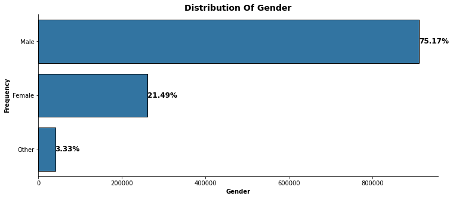

```python
#plot of Gender Distirbution
graph(df,'gender')
```

#### Observation

The Male Gender had most of the trips covering over 75% of the total trips, followed by the Female Gender group with 21.5%

#### Question 2:

What type of Users made use of the bikes mostly for the trips?

#### Visualisation

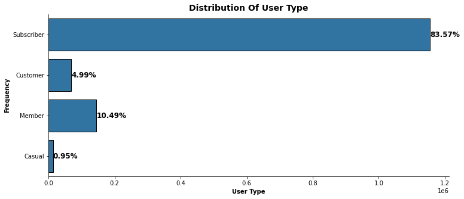

```python
#plot of User_Type Distirbution
graph(df, 'user_type')
```

#### Observation:

It was noticed that the bike users who subscribed for the trips dominated the various trips with over 83% of the total number of users

#### Question 3:

Which Location has the highest trips?

#### Visualisation

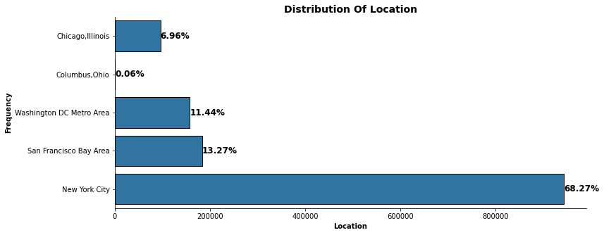

```python
#graph plot of location Distribution
graph(df, 'location')
```

#### Observation:

Bike Riders from New York City dominated the Trips with over 68% of the total trips, followed by San Francisco Bay Area with 13.3%, Chicago with 7%, while Columbus has the least with 0.1%.

#### Question 4:

What is the Distribution of Age across the Trips?

#### Visualisation

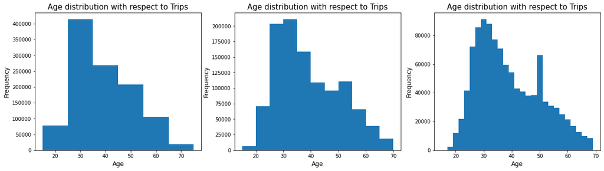

```python
#we would agree that bike riders beyond 1949, which is 70 by 2019
#when this data was compiled, because ages beyond 70 may not possess the strength
plt.figure(figsize=(20,5))

#first subplot with bins of step size 10
plt.subplot(1,3,1)
bins=np.arange(15,df_clean.age.max()+10, 10)
plt.hist(data = df_clean, x = 'age', bins=bins)
plt.title('Age distribution with respect to Trips', fontsize=15)
plt.xlabel('Age', fontsize=12)
plt.ylabel('Frequency', fontsize=12)
#second subplot with bins of step size 5
plt.subplot(1,3,2)
bins=np.arange(15,df_clean.age.max()+5, 5)
plt.hist(data = df_clean, x = 'age', bins=bins)
plt.title('Age distribution with respect to Trips', fontsize=15)
plt.xlabel('Age', fontsize=12)
plt.ylabel('Frequency', fontsize=12)
#third subplot with bins of step size 2
plt.subplot(1,3,3)
bins=np.arange(15,df_clean.age.max()+2, 2)
plt.hist(data = df_clean, x = 'age', bins=bins)
plt.title('Age distribution with respect to Trips', fontsize=15)
plt.xlabel('Age', fontsize=12)
plt.ylabel('Frequency', fontsize=12);
```

#### Observation

Bike Riders between Ages 25 and 35 years participated mostly in the Trip amounting to over 400,000 participants,of this age width(25-35years), ages between 30 and 35 years of over 200,000 participated mostly in the trip and also of this age width (30-35 years), ages between 30 and 32 years were the dominant participants with almost 100,000 of them.

#### Question5:

At which Speed did the riders rode the most?

#### Visualisation

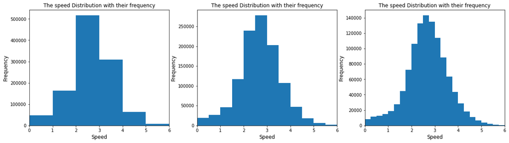

```python
plt.figure(figsize=(20,5))
#first subplot with bins of step size 1
plt.subplot(1,3,1)
bins=np.arange(0,df_clean.speed.max()+1, 1)
plt.hist(data=df_clean, x='speed', bins=bins)
plt.xlim(0,6)
plt.title('The speed Distribution with their frequency')
plt.xlabel('Speed', fontsize=12)
plt.ylabel('Frequency', fontsize=12)
#second subplot with bins of step size 0.5
plt.subplot(1,3,2)
bins=np.arange(0,df_clean.speed.max()+0.5, 0.5)
plt.hist(data=df_clean, x='speed', bins=bins)
plt.xlim(0,6)
plt.title('The speed Distribution with their frequency')
plt.xlabel('Speed', fontsize=12)
plt.ylabel('Frequency', fontsize=12)
#third subplot with bins of step size 0.25
plt.subplot(1,3,3)
bins=np.arange(0,df_clean.speed.max()+0.25, 0.25)
plt.hist(data=df_clean, x='speed', bins=bins)
plt.xlim(0,6)
plt.title('The speed Distribution with their frequency')
plt.xlabel('Speed', fontsize=12)
plt.ylabel('Frequency', fontsize=12);
```

#### Question 6

what distance did the Trip riders travelled the most?

#### Visualisation

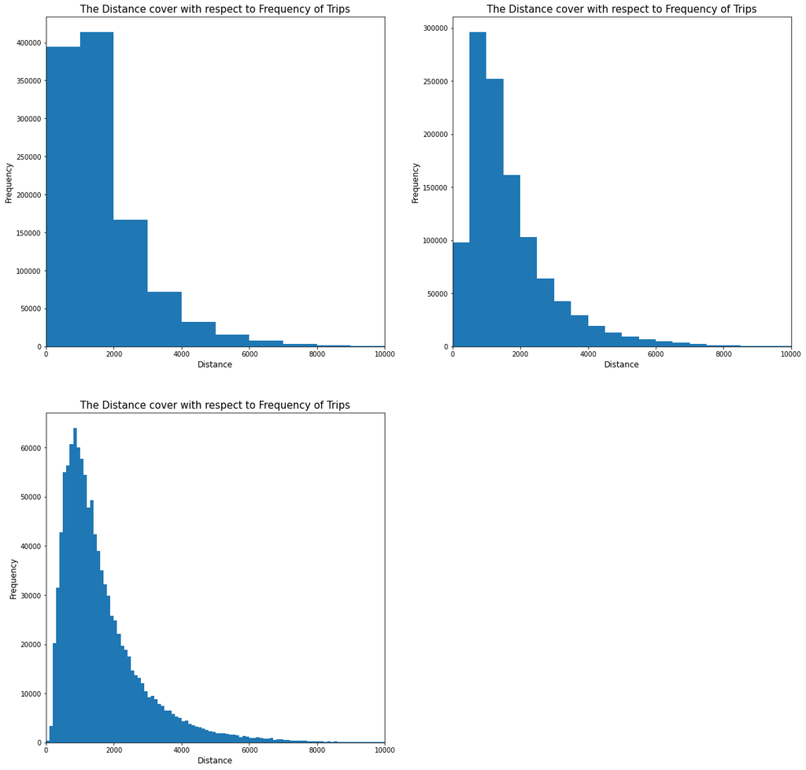

```python
plt.figure(figsize=(20,20))
#first subplot with bins of step size 1000
plt.subplot(2,2,1)
bins=np.arange(0,df_clean.distance.max()+1000, 1000)
plt.hist(data=df_clean, x='distance', bins=bins)
plt.xlim(0,10000)
plt.title('The Distance cover with respect to Frequency of Trips', fontsize=15)
plt.xlabel('Distance', fontsize=12)
plt.ylabel('Frequency', fontsize=12)
#second subplot with bins of step size 500
plt.subplot(2,2,2)
bins=np.arange(0,df_clean.distance.max()+500, 500)
plt.hist(data=df_clean, x='distance', bins=bins)
plt.xlim(0,10000)
plt.title('The Distance cover with respect to Frequency of Trips', fontsize=15)
plt.xlabel('Distance', fontsize=12)
plt.ylabel('Frequency', fontsize=12)
#third subplot with bins of step size 100
plt.subplot(2,2,3)
bins=np.arange(0,df_clean.distance.max()+100, 100)
plt.hist(data=df_clean, x='distance', bins=bins)
plt.xlim(0,10000)
plt.title('The Distance cover with respect to Frequency of Trips', fontsize=15)
plt.xlabel('Distance', fontsize=12)
plt.ylabel('Frequency', fontsize=12);
```

#### Observation

Most riders of over 400,000 persons went on a trip of between 500m and 2000metres and of the over 400,000 persons, about 290,000 persons went on the trip of between 500m and 1000metres,also of these 290,000 persons, about 65,000 perons travelled most in thr trip between 700 and 800m

#### Question 7:

Which Trip Duration was dominant the most?

#### Visualisation

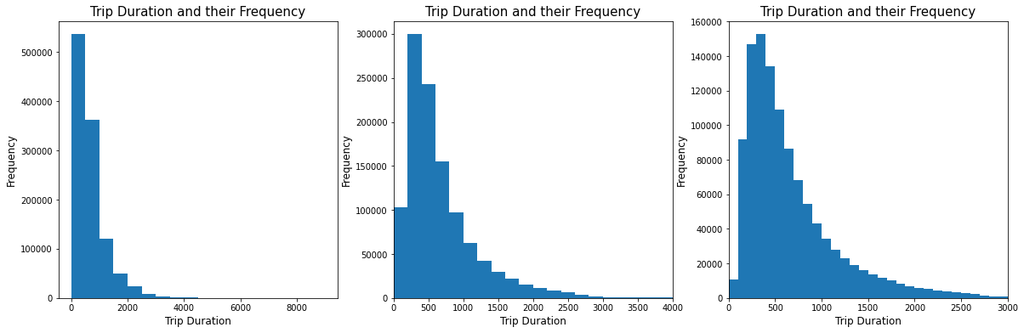

```python
plt.figure(figsize=(20,6))
#first subplot with bins of step size 500
plt.subplot(1,3,1)
bins=np.arange(0,9000+500, 500)
plt.hist(data=df_clean, x='trip_duration', bins=bins)
plt.title('Trip Duration and their Frequency', fontsize=15)
plt.ylabel('Frequency', fontsize=12)
plt.xlabel('Trip Duration', fontsize=12)
#second subplot with bins of step size 200
plt.subplot(1,3,2)
bins=np.arange(0,9000+200, 200)
plt.hist(data=df_clean, x='trip_duration', bins=bins)
plt.xlim(0,4000)
plt.title('Trip Duration and their Frequency', fontsize=15)
plt.ylabel('Frequency', fontsize=12)
plt.xlabel('Trip Duration', fontsize=12)
#third subplot with bins of step size 100
plt.subplot(1,3,3)
bins=np.arange(0,9000+100, 100)
plt.hist(data=df_clean, x='trip_duration', bins=bins)
plt.xlim(0,3000)
plt.title('Trip Duration and their Frequency', fontsize=15)
plt.ylabel('Frequency', fontsize=12)
plt.xlabel('Trip Duration', fontsize=12);
```

### Discuss the distribution(s) of your variable(s) of interest. Were there any unusual points? Did you need to perform any transformations?

> Distribution of variables of interest include some null values which was dropped. They also include some duplicated values like the coordinates(longitudes and latitudes) which were also dropped

### Of the features you investigated, were there any unusual distributions? Did you perform any operations on the data to tidy, adjust, or change the form of the data? If so, why did you do this?

> I investigated the Distance travelled the most which i got by calculating the distance between the Latitude and Longitude coordinates. I also investigated the Speed by dividing the Distance by trip duration. I also Calculate Ages by extracting from the Birth year column and subtracting from current date of dataset

## Bivariate Exploration

#### Question 8:

Which Gender has the highest occurence among the location?

#### Visualisation

```python
#to group by location and gender, gather the series into a df for a heatmap.
ct_count=df.groupby(['location', 'gender']).size()
#convert the the series into df
ct_count=ct_count.reset_index(name='count')
#use pivot to rearrange the df
ct_count=ct_count.pivot(index='location',columns='gender', values='count')
```

```
''
```

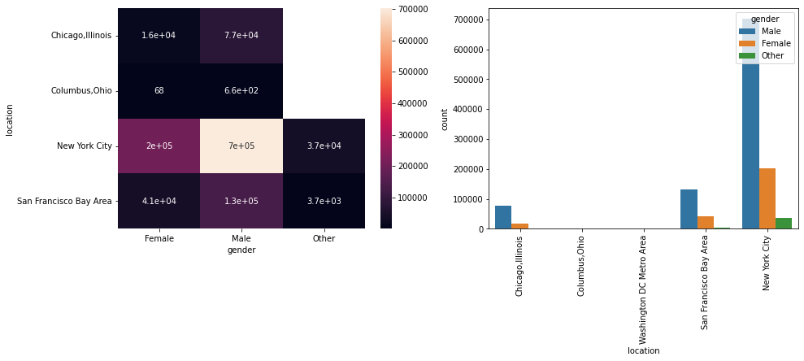

```python
plt.figure(figsize=(15,5))
#first subplot of heatmap
plt.subplot(1,2,1)
sns.heatmap(ct_count,annot=True)
#second subplot of clusterd bar charts
plt.subplot(1,2,2)
sns.countplot(data=df, x='location', hue='gender')
plt.xticks(rotation=90)
;
```

#### Observation:

In all locations, Newyork city is dominant in the number of trips occurence across the genders. The Male gender has 700,000 riders from Newyork city, 200,000 female riders, and 30,000 other riders.

#### Question 9:

What the distribution across Genders and Ages?

#### Visualisation

```
''
```

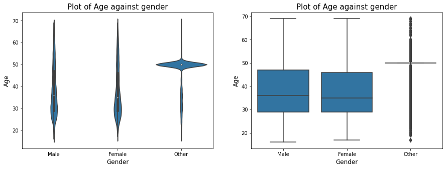

```python
ax = plt.subplots(figsize=(15,5))
base_color=sns.color_palette()[0]
#subplot of violin plot
plt.subplot(1,2,1)
ax1=sns.violinplot(data=df_clean, y='age', x='gender', color=base_color)
plt.ylabel('Age', fontsize=12)
plt.xlabel('Gender', fontsize=12)
plt.title('Plot of Age against gender', fontsize=15)
#subplot of box plot
plt.subplot(1,2,2)
sns.boxplot(data=df_clean, y='age', x='gender', color=base_color)
plt.ylabel('Age', fontsize=12)
plt.xlabel('Gender', fontsize=12)
plt.title('Plot of Age against gender', fontsize=15)
;
```

#### Observation:

50% of Males are between the Ages of 30 and 48 years, 30 and 47 years for females. while 25% of Males constitutes the Older riders between 48 and 69 for males and 47 and 69 years old for Females.

#### Question 10:

Which Gender had the highest speed?

#### Visualisation

```
''
```

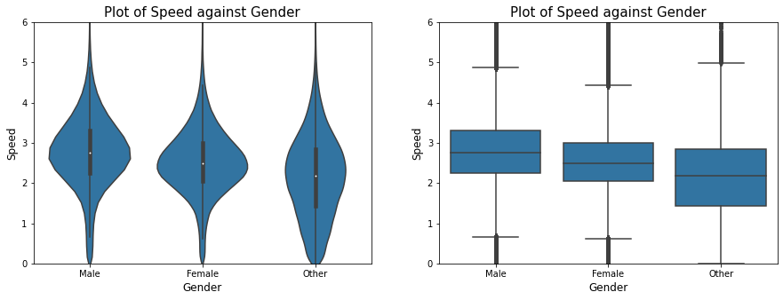

```python
#sns.scatterplot(y='speed', x='gender', data=df_clean, hue='gender', x_jitter=0.3,alpha=1/20);
ax = plt.subplots(figsize=(15,5))
#subplot of violin plot
plt.subplot(1,2,1)
ax1=sns.violinplot(data=df_clean, y='speed', x='gender', color=base_color)
plt.ylabel('Speed', fontsize=12)
plt.xlabel('Gender', fontsize=12)
plt.ylim(0,6)
plt.title('Plot of Speed against Gender', fontsize=15)
#subplot of box plot
plt.subplot(1,2,2)
sns.boxplot(data=df_clean, y='speed', x='gender', color=base_color)
plt.ylabel('Speed', fontsize=12)
plt.xlabel('Gender', fontsize=12)
plt.ylim(0,6)
plt.title('Plot of Speed against Gender', fontsize=15)
;
```

#### Question 11:

Which Gender covered the highest distance?

#### Visualisation

```
''
```

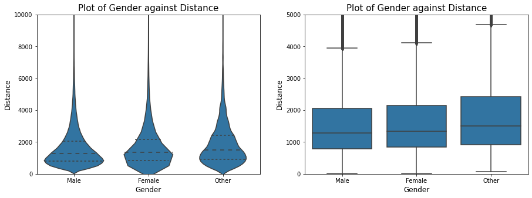

```python
ax = plt.subplots(figsize=(15,5))
#subplot of violinplot
plt.subplot(1,2,1)
ax1=sns.violinplot(data=df_clean, y='distance', x='gender', color=base_color, inner='quartile')
plt.ylabel('Distance', fontsize=12)
plt.xlabel('Gender', fontsize=12)
plt.ylim(0,10000)
plt.title('Plot of Gender against Distance',fontsize=15)
#subplot of boxplot
plt.subplot(1,2,2)
sns.boxplot(data=df_clean, y='distance', x='gender', color=base_color)
plt.ylabel('Distance', fontsize=12)
plt.xlabel('Gender', fontsize=12)
plt.ylim(0,5000)
plt.title('Plot of Gender against Distance',fontsize=15)
;
```

#### Question 12:

which of the users has the highest speed?

#### Visualisation

```
''
```

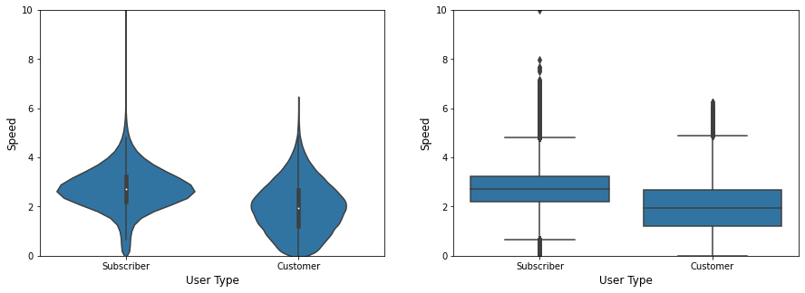

```python
#sns.scatterplot(y='speed', x='user_type', data=df_clean, hue='user_type', x_jitter=0.3,alpha=1/20);
ax = plt.subplots(figsize=(15,5))

plt.subplot(1,2,1)
ax1=sns.violinplot(data=df_clean, x='user_type', y='speed', color=base_color)
plt.xlabel('User Type', fontsize=12)
plt.ylabel('Speed', fontsize=12)
plt.ylim(0,10)
plt.subplot(1,2,2)
sns.boxplot(data=df_clean, x='user_type', y='speed', color=base_color)
plt.xlabel('User Type', fontsize=12)
plt.ylabel('Speed', fontsize=12)
plt.ylim(0,10)
;
```

#### Question 13:

Which of the locations has the Oldest Rider?

#### Visualisation

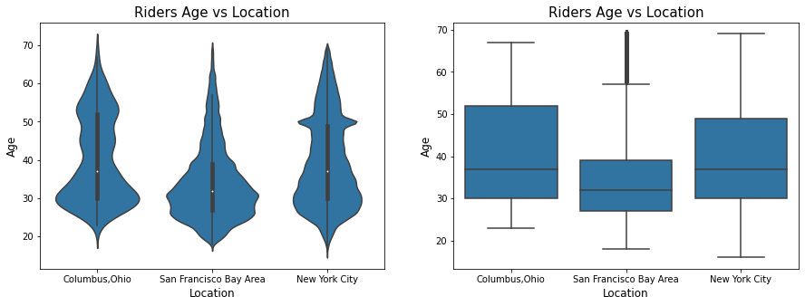

```python
#sns.scatterplot(x='age', y='location', data=df_clean, x_jitter=0.3);
ax = plt.subplots(figsize=(15,5))
#subplot of Violinplot
plt.subplot(1,2,1)
ax1=sns.violinplot(data=df_clean, y='age', x='location', color=base_color)
plt.ylabel('Age', fontsize=12)
plt.xlabel('Location', fontsize=12)
plt.title('Riders Age vs Location', fontsize=15)
#subplot of boxplot
plt.subplot(1,2,2)
sns.boxplot(data=df_clean, y='age', x='location', color=base_color)
plt.ylabel('Age', fontsize=12)
plt.xlabel('Location', fontsize=12)
plt.title('Riders Age vs Location', fontsize=15);
```

#### Question 14:

Which Gender has the highest occurence among the Users?

#### Visualisation

```python
#to group by user_type and gender, gather the series into a df for a heatmap.
ct_counts=df.groupby(['user_type', 'gender']).size()
#convert the the series into df
ct_counts=ct_counts.reset_index(name='count')
#use pivot to rearrange the df
ct_counts=ct_counts.pivot(index='user_type',columns='gender', values='count')
```

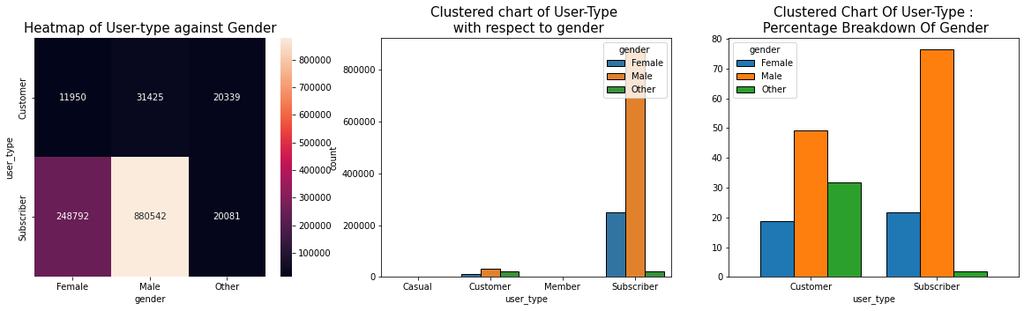

```python
#plot of user_type vs gender
plt.figure(figsize=(20,5))
#first subplot of Heat Map
plt.subplot(1,3,1)
sns.heatmap(ct_counts,annot=True, fmt='.0f')
plt.title('Heatmap of User-type against Gender', fontsize=15)
#second subplot of clustered Bar Chart
plt.subplot(1,3,2)
sns.countplot(data=df, x='user_type', hue='gender',edgecolor='black',
             order=sorted(df.dropna(subset=['user_type'])['user_type'].unique()),
             hue_order=sorted(df.dropna(subset=['gender'])['gender'].unique()))
plt.title('Clustered chart of User-Type \n with respect to gender', fontsize=15)
#Third subplot of clustered Bar Chart
plt.subplot(1,3,3)
ax=plt.gca()
#
df.groupby('user_type')['gender'].value_counts(normalize=True).unstack().mul(100).plot.bar(edgecolor='black',rot=0,width=0.8, ax=ax)
plt.title('Clustered chart of User-Type :\n percentage breakdown of gender'.title(), fontsize=15);
```

#### Question 15:

Which of the Users has the highest occurence among the different Locations?

#### Visualisation

```python
#to group by location and gender, gather the series into a df for a heatmap.
counts=df.groupby(['user_type', 'location']).size()
#convert the the series into df
counts=counts.reset_index(name='count')
#use pivot to rearrange the df
counts=counts.pivot(index='user_type',columns='location', values='count')
```

```
''
```

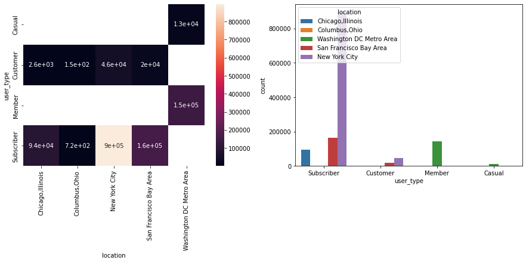

```python
#plot of location vs gender
plt.figure(figsize=(15,5))
#first subplot
plt.subplot(1,2,1)
sns.heatmap(counts,annot=True)
#second subplot
plt.subplot(1,2,2)
sns.countplot(data=df, x='user_type', hue='location')
;
```

#### Observation

Of all the Users, Newyork city has the highest number of subscribers of 900,000 persons, likewise the highest number of customers of 46,000 persons. Persons from Chicago, Illinois are mainly Subscriber riders of 94,000 of them. Washington DC Metro Area are the only Member Users with 150,000 persons.

### How did the feature(s) of interest vary with other features in the dataset?

> The Female gender covered more distance than the Male gender

> New york city has most riders across all genders in this dataset

### Did you observe any interesting relationships between the other features (not the main feature(s) of interest)?

> Chicago and Columbus has only Male and Female Genders, no Other gender.

## Multivariate Exploration

#### Question 16:

Of the locations which of the Age has the highest speed?

#### Visualisation

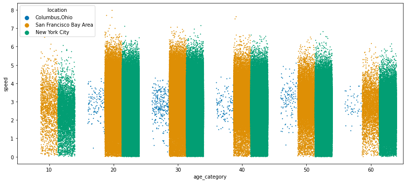

```python
#some age values contains Nan
#we drop them
df_cleans=df_clean.dropna(subset=['age']).copy()
# we then create age category
df_cleans['age_category']=((df_cleans.age//10)*10).astype(int)
#figure size
plt.figure(figsize=[14,6])
# plot of speed less than 10m/s against age with their respective locations
sns.stripplot(data=df_cleans.query('speed<10'), x='age_category', y='speed', hue='location', size=2, palette='colorblind', jitter=0.4, dodge=True);
```

#### Observation:

Overall, Riders from Newyork City and San Francisco Bay Area dominated the various speeds, while riders from Columbus, Ohio were not many compared to the rest. The Columbus riders do not any teenage rider like the rest, also riders in their 20s and 60s are not as mush as riders in their 30s, 40s and 50s in Columbus.

#### Question 17:

Of the Ages, which Gender has the highest Speed?

#### Visualisation

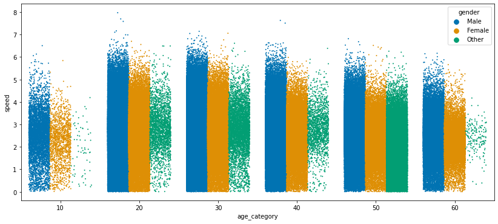

```python
#figure size
plt.figure(figsize=[14,6])
# plot of speed less than 10m/s against age with their respective genders
sns.stripplot(data=df_cleans.query('speed<10'), x='age_category', y='speed', hue='gender', size=2, palette='colorblind', jitter=0.4, dodge=True);
```

#### Observation:

Riders of other gender are seen to be less dominant in the teenagers and riders in their 60s as seen in the rest of the Age category. The Male and Female genders are seen to be most dominant in all, while the male gender is seen to have attained the highest speed of 8m/s.

#### Question 18

What is the relationship between Age and distance with respect to gender and User?

#### Visualisation

```
''
```

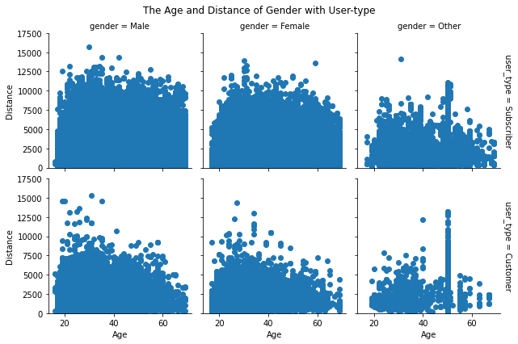

```python
#a facetgrid plot of gender on the column and user type on the row
g=sns.FacetGrid(data=df_clean, col='gender', row='user_type', margin_titles=True)
# each facetgrid to carry a scatter plot of age against distance covered
g.map(plt.scatter,'age', 'distance')
#axis labels
g.axes[1,0].set_xlabel('Age')
g.axes[1,1].set_xlabel('Age')
g.axes[1,2].set_xlabel('Age')
g.axes[0,0].set_ylabel('Distance')
g.axes[1,0].set_ylabel('Distance')
g.fig.subplots_adjust(top=0.9)
#title of the figure
g.fig.suptitle('The Age and Distance of Gender with User-type')
plt.ylim(0,17500)
;
```

#### Observation:

The Subslide shows the relationship between The distatnce covered by the riders and Age of the riders with respect to each gender and respective user type. The male gender of the Subscriber user type and Age around 33years is seen to cover the highest distance of more than 15,000 metres, while for the Customer User typeThe Male gender was also with the highest distance covered of above 15000metres also about 33 years of age.

#### Question 19:

What is the relationship between Age and Trip Duration with resect to Genders?

#### Visualisation

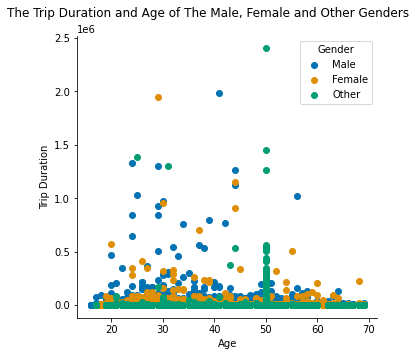

```python
#facetgrid with hue as gender
g=sns.FacetGrid(data=df_clean,hue='gender',height=5,palette='colorblind')
#facetgrid with scatterplot of Age against trip duration
g.map(plt.scatter, 'age','trip_duration')
#figure legend
plt.legend(['Male','Female','Other'], title='Gender')
g.fig.subplots_adjust(top=0.9)
#axis labels
plt.xlabel('Age')
plt.ylabel('Trip Duration')
#figure title
g.fig.suptitle('The Trip Duration and Age of The Male, Female and Other Genders');
```

#### Observation

This sublide shows the relationship between Age of the riders and trip duration with respect to the genders. it was noticed that the riders with ag 50 years tarried most in the ride recorded as the other gender while the male and female came second and third respectively.